# Predictive Modeling of Trial Outcomes Using Neural Activity and Stimulus Contrasts in Mouse Visual Cortex

06/06/2023

Abstract:

Section 1 Introduction:

This project aims to build a predictive model to predict the outcome or feedback type of each trial using the neural activity data along with the stimuli (the left and right contrasts). The data set used in this project is from a study by Steinmetz et al. (2019) and involves 10 mice and 39 experimental sessions. The mice were presented with visual stimuli of varying contrast levels and had to make decisions using a wheel, with feedback in the form of rewards or penalties provided based on their decisions. Spike train data, representing neuron firing, was recorded from the mice’s visual cortex. Our model is based on 18 sessions from four mice: Cori, Forssmann, Hench, and Lederberg. We took these sessions and identify shared patterns and/or session-specific differences to improve prediction performance.

We aim to first understand the neural activity patterns associated with visual stimulus processing and gain insights into underlying mechanisms. The feedback outcomes are as follows:

- When left contrast > right contrast, success (1) if turning the wheel to the right and failure (-1) otherwise.
- When right contrast > left contrast, success (1) if turning the wheel to the left and failure (-1) otherwise.
- When both left and right contrasts are zero, success (1) if holding the wheel still and failure (-1) otherwise.
- When left and right contrasts are equal but non-zero, left or right will be randomly chosen (50%) as the correct choice.

The activity of the neurons in the mice’s visual cortex was recorded during the trials and made available in the form of spike trains, which are collections of timestamps corresponding to neuron firing. In this project, we focus specifically on Mouse, ContrastLeft, and Brain Area to build our Feedback prediction model.

Unzipping the files

```r
zip_file_path <- "./sessions.zip"

# Set the destination folder to extract the files
destination_folder <- "./Data"

# Create the Data folder if it doesn't exist
dir.create(destination_folder, showWarnings = FALSE)

# Unzip the sessions.zip file to the Data folder
unzip(zipfile = zip_file_path, exdir = destination_folder)

data_files <- list.files(destination_folder)
```

This here just prints out some of the mice and dates of each session.

```r
session=list()
for(i in 1:18){
  session[[i]]=readRDS(paste('./Data/session',i,'.rds',sep=''))
   print(session[[i]]$mouse_name)
   print(session[[i]]$date_exp)
}
```

```
## [1] "Cori"
## [1] "2016-12-14"
## [1] "Cori"
## [1] "2016-12-17"
## [1] "Cori"
## [1] "2016-12-18"
## [1] "Forssmann"
## [1] "2017-11-01"
## [1] "Forssmann"
## [1] "2017-11-02"
## [1] "Forssmann"
## [1] "2017-11-04"
## [1] "Forssmann"
## [1] "2017-11-05"
## [1] "Hench"
```

[output cut: 21 more lines]

Part 2. Exploratory data analysis. In this part, we will explore the features of the data sets in order to build our prediction model. In particular, we would like to (i) describe the data structures across sessions (e.g., number of neurons, number of trials, stimuli conditions, feedback types), (ii) explore the neural activities during each trial, (iii) explore the changes across trials, and (iv) explore homogeneity and heterogeneity across sessions and mice.

Part (i) describe the data structures across sessions (e.g., number of neurons, number of trials, stimuli conditions, feedback types)

```r
library(knitr)

# Create an empty data frame to store the information
session_summary <- data.frame(Session = numeric(),
                              Brain_Area = numeric(),
                              Mouse_Name = character(),
                              Num_Trials = numeric(),
                              Unique_Stimuli = character(),
                              Unique_Feedback = character())

for (i in 1:18) {
  session_data <- session[[i]]

  # Gather the session information
  session_info <- data.frame(Session = i,
                             Brain_Area = length(unique(session_data$brain_area)),
                             Mouse_Name = unique(session_data$mouse_name),
                             Num_Trials = length(session_data$feedback_type),
                             Unique_Stimuli = paste(unique(c(session_data$contrast_left, session_data$contrast_right)), collapse = ", "),
                             Unique_Feedback = paste(unique(session_data$feedback_type), collapse = ", "),
                             stringsAsFactors = FALSE)

  session_summary <- rbind(session_summary, session_info)
}

kable(session_summary)
```

| Session | Brain_Area | Mouse_Name | Num_Trials | Unique_Stimuli | Unique_Feedback |
| --- | --- | --- | --- | --- | --- |
| 1 | 8 | Cori | 114 | 0, 0.5, 1, 0.25 | 1, -1 |
| 2 | 5 | Cori | 251 | 1, 0.25, 0.5, 0 | -1, 1 |
| 3 | 11 | Cori | 228 | 0.5, 1, 0, 0.25 | 1, -1 |
| 4 | 11 | Forssmann | 249 | 0, 0.5, 0.25, 1 | 1, -1 |
| 5 | 10 | Forssmann | 254 | 0, 0.25, 0.5, 1 | 1, -1 |
| 6 | 5 | Forssmann | 290 | 0.25, 0, 1, 0.5 | 1, -1 |
| 7 | 8 | Forssmann | 252 | 1, 0, 0.25, 0.5 | 1, -1 |
| 8 | 15 | Hench | 250 | 0, 1, 0.5, 0.25 | 1, -1 |
| 9 | 12 | Hench | 372 | 1, 0.5, 0, 0.25 | 1, -1 |
| 10 | 13 | Hench | 447 | 0, 0.5, 1, 0.25 | -1, 1 |
| 11 | 6 | Hench | 342 | 0.5, 0, 1, 0.25 | 1, -1 |
| 12 | 12 | Lederberg | 340 | 0, 1, 0.25, 0.5 | 1, -1 |
| 13 | 15 | Lederberg | 300 | 0, 0.5, 0.25, 1 | -1, 1 |
| 14 | 10 | Lederberg | 268 | 1, 0, 0.25, 0.5 | 1, -1 |
| 15 | 8 | Lederberg | 404 | 0.5, 0, 0.25, 1 | 1, -1 |
| 16 | 6 | Lederberg | 280 | 1, 0, 0.5, 0.25 | 1, -1 |
| 17 | 6 | Lederberg | 224 | 0, 0.5, 0.25, 1 | -1, 1 |
| 18 | 10 | Lederberg | 216 | 0.5, 1, 0, 0.25 | 1, -1 |

Above is a general outline of data structure across sessions. This providees session-specific information such as the session number, number of unique brain areas, mouse name, number of trials, unique stimuli (combination of left and right contrasts), and unique feedback types.

```r
library(data.table)

combined_data <- list()

suppressWarnings(
  for (i in 1:18) {
    # Extract the variables of interest from session[[i]]
    feedback_type <- unlist(session[[i]][3])
    contrast_left <- unlist(session[[i]][1])
    contrast_right <- unlist(session[[i]][2])
    mouse_name <- session[[i]]$mouse_name
    brain_area <- session[[i]]$brain_area
    date_exp <- session[[i]]$date_exp
    spks <- session[[i]]$spks

    # Create a data table from the variables
    session_data <- data.table(
     feedback_type = feedback_type,
     contrast_left = contrast_left,
      contrast_right = contrast_right,
      mouse_name = mouse_name,
      brain_area = brain_area,
      date_exp = date_exp,
      spks = spks
    )

    # Append session_data to the combined_data list
    combined_data[[i]] <- session_data
  }
)
head(combined_data[[1]])
```

[output not shown]

This dataframe above has the results for each session in a different dataframe so I was able to more easily visualize the data that I’m working with. From this, I was able to see that the spks column is in <dbl [734 × 40]> form. I am not printing the graphs because that would be 18 very long dataframes to look at, but this was helpful for my personal visualization.

Part (ii) explore the neural activities during each trial.

```r
i_session <- 8 # indicator for this session
i_trial <- 1 # indicator for this trial
spikes_trial <- session[[i_session]]$spks[[i_trial]]
area <- session[[i_session]]$brain_area

spike_counts <- apply(spikes_trial, 1, sum)
average_spikes_tapply <- tapply(spike_counts, area, mean)
df <- data.frame(area = area, spikes = spike_counts)

library(dplyr)
average_spikes_dplyr <- df %>%
  group_by(area) %>%
  summarize(mean_spikes = mean(spikes))

# Function to calculate average spike counts by area
average_spike_area <- function(i_trial, session_data) {
  spikes_trial <- session_data$spks[[i_trial]]
  area <- session_data$brain_area
  spike_counts <- apply(spikes_trial, 1, sum)
  average_spikes_tapply <- tapply(spike_counts, area, mean)
  return(average_spikes_tapply)
}

average_spike_area(1, session_data = session[[i_session]])
```

```
##       CA1       CA3        DG       ILA        LD        LP       LSr       MOs
## 0.6785714 1.3529412 0.8181818 1.0069444 1.4634146 1.4000000 0.0000000 0.5132743
##        PL        PO      root       SUB        TT      VISa      VISp
## 1.0138889 1.3725490 0.0000000 1.2647059 0.6463415 0.9682540 0.6041667
```

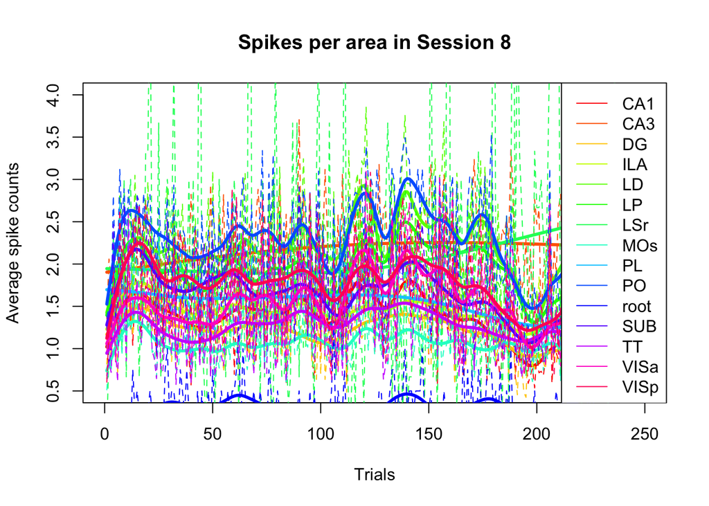

```r
num_trials <- length(session[[i_session]]$feedback_type)
num_areas <- length(unique(session[[i_session]]$brain_area))

# Create a data frame for trial summary
trial_summary <- matrix(nrow = num_trials, ncol = num_areas + 4)
for (i_trial in 1:num_trials) {
  trial_summary[i_trial, ] <- c(average_spike_area(i_trial, session_data = session[[i_session]]), session[[i_session]]$feedback_type[i_trial], session[[i_session]]$contrast_left[i_trial], session[[i_session]]$contrast_right[i_trial], i_trial)
}
colnames(trial_summary) <- c(names(average_spike_area(i_trial, session_data = session[[i_session]])), 'feedback', 'contrast_left', 'contrast_right', 'trial_id')

library(tibble)
trial_summary <- as_tibble(trial_summary)
area_colors <- rainbow(n = num_areas)
plot(0 ~ 1, col = 'white', xlim = c(0, num_trials), ylim = c(0.5, 4), xlab = "Trials", ylab = "Average spike counts", main = paste("Spikes per area in Session", i_session))

# Draw lines and smooth spline for each area
for (i in 1:num_areas) {
  lines(y = trial_summary[[i]], x = trial_summary$trial_id, col = area_colors[i], lty = 2, lwd = 1)
  lines(smooth.spline(trial_summary$trial_id, trial_summary[[i]]), col = area_colors[i], lwd = 3)
}

legend("topright", legend = colnames(trial_summary)[1:num_areas], col = area_colors, lty = 1)
```

In the plot above, I am exploring the neural activities in each of the brain regions and the average spike counts for different parts of the brain in this randomly chosen session 8. Here we can see that a dark blue PO line has the most average spike counts per session. We also see that spike counts vary very much by brain region and trial, with some trials having significantly more average spike counts than others.

Part (iii) explore the spk changes across trials

```
## Session: 8
##
## Trial Data:
##   Trial Spike_Count
## 1     1        1201
## 2     2        1384
## 3     3        1364
## 4     4        2434
## 5     5        1526
## 6     6        1566
```

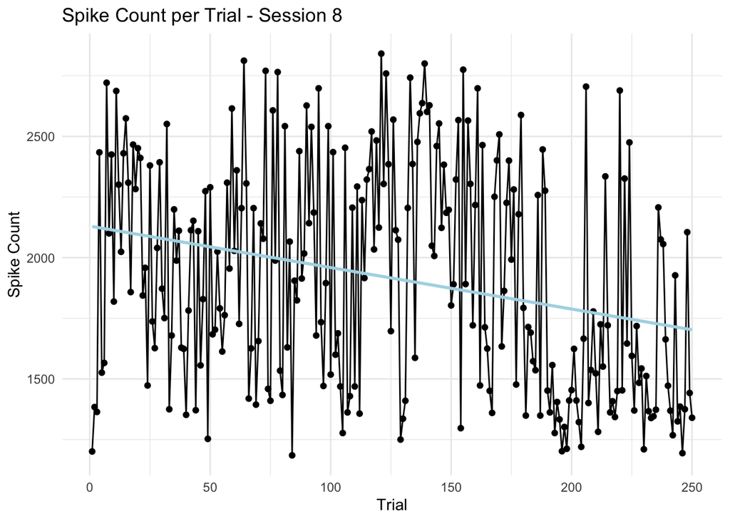

```r
library(ggplot2)

session_data <- session
spike_trains <- session$spks

for (i in 8) {
  session_data <- session[[i]]

  cat("Session:", i, "\n")

  num_trials <- length(session_data$feedback_type)

  trial_data <- data.frame(Trial = numeric(num_trials),
                           Spike_Count = numeric(num_trials),
                           stringsAsFactors = FALSE)

  for (j in 1:num_trials) {
    spike_train <- session_data$spks[[j]]
    spike_count <- apply(spike_train, 1, sum)
    total_spike_count <- sum(spike_count)
    trial_data$Trial[j] <- j
    trial_data$Spike_Count[j] <- total_spike_count
  }

  cat("\nTrial Data:\n")
  print(head(trial_data))

  p <- ggplot(trial_data, aes(x = Trial, y = Spike_Count)) +
    geom_line() +
    geom_point() +
    geom_smooth(method = "lm", se = FALSE, color = "lightblue") +
    labs(x = "Trial", y = "Spike Count",
         title = paste("Spike Count per Trial - Session", i)) +
    theme_minimal()

  print(p)
}
```

```r
summary(trial_data)
```

```
##      Trial         Spike_Count
##  Min.   :  1.00   Min.   :1185
##  1st Qu.: 63.25   1st Qu.:1472
##  Median :125.50   Median :1868
##  Mean   :125.50   Mean   :1915
##  3rd Qu.:187.75   3rd Qu.:2308
##  Max.   :250.00   Max.   :2841
```

Above is a dataframe showing the spike counts per trial for the randomly chosen session 8, as well as a visual representation of the session 8 data. There is a light blue line on the graph which is the line of best fit. Here is also a the head of the session 8 dataset showing how spike train data looks. The spike count is essentially just counting the numbers in the spike train and adding it up.

Part (iv) explore homogeneity and heterogeneity across sessions and mice

```r
suppressWarnings({

  library(data.table)

  mouse_groups <- c(rep("Cori", 3), rep("Forssmann", 4), rep("Hench", 4), rep("Lederberg", length(session) - 11))
  all_spike_trains <- list()
  for (i in 1:length(session)) {
    session_data <- session[[i]]

   session_spike_trains <- list()

   for (j in 1:length(session_data$spks)) {
     spike_train <- session_data$spks[[j]]

     # Add the spike train data to the session_spike_trains list
     session_spike_trains[[j]] <- spike_train
    }

    # Add the session_spike_trains list to the all_spike_trains list
   all_spike_trains[[i]] <- session_spike_trains
  }

# Calculate the mean spike count for each session and trial
  mean_spike_counts <- sapply(all_spike_trains, function(session_spikes) {
    sapply(session_spikes, function(spike_train) mean(rowSums(spike_train)))
  })

  session_mean_spike_counts <- sapply(mean_spike_counts, mean)

  mouse_mean_spike_counts <- tapply(unlist(mean_spike_counts), rep(1:length(session), sapply(mean_spike_counts, length)), mean)

  overall_mean_spike_count <- mean(unlist(mean_spike_counts))

  within_session_heterogeneity <- sapply(mean_spike_counts, function(session_counts) {
    sum((session_counts - session_mean_spike_counts)^2)
  })

# Calculate the between-session heterogeneity
  between_session_heterogeneity <- sum((session_mean_spike_counts - overall_mean_spike_count)^2)
# Create a vector to repeat mouse group names based on the number of trials
  mouse_groups_rep <- rep(mouse_groups, sapply(mean_spike_counts, length))
# Calculate the mouse-wise mean spike count
  mouse_mean_spike_counts <- tapply(unlist(mean_spike_counts), mouse_groups_rep, mean)
  overall_mean_spike_count <- mean(unlist(mean_spike_counts))
  between_mouse_heterogeneity <- sum((mouse_mean_spike_counts - overall_mean_spike_count)^2)

  cat("Within-Session Heterogeneity:\n")
  print(within_session_heterogeneity)
  cat("\nBetween-Session Heterogeneity:\n")
  print(between_session_heterogeneity)
  cat("\nBetween-Mouse Heterogeneity:\n")
  print(between_mouse_heterogeneity)
})
```

```
## Within-Session Heterogeneity:
##  [1]  33.09830  53.61280 227.71644 126.64037  75.07185 201.36177  70.45673
##  [8] 110.39702 120.83506 117.72477 144.61701 105.36299 420.59482  95.92090
## [15]  91.91851  91.41558  57.50594  61.65096
##
## Between-Session Heterogeneity:
## [1] 3.436578
##
## Between-Mouse Heterogeneity:
## [1] 0.2494297
```

Above is the code to explore general homogeneity and heterogeneity amongst the spikes accross sessions. Between-mouse heterogeneity is a measure of the variability in mean spike counts across different mice. Specifically, it represents the sum of squared differences between the mean spike counts of each mouse group and the overall mean spike count.

There is a lower value of between-mouse heterogeneity which suggests more similarity in the mean spike counts between mice, indicating a degree of consistency in neural spk activity patterns across the different mice.

There is a high Within-Session Heterogeneity, which indicates that there is significant variation in spike counts within each session. This suggests that the neural activity patterns during different trials within the same session are diverse and not consistent. This isn’t super informative towards finding out which variables most impact feedback so let’s take a closer look at the variables using ANOVA.

```r
library(data.table)

# Create a data frame to store the variables of interest
data <- data.frame(Session = factor(),
                   Mouse = character(),
                   FeedbackType = numeric(),
                   ContrastLeft = numeric(),
                   ContrastRight = numeric(),
                   BrainArea = character(),
                   stringsAsFactors = FALSE)

for (i in 1:18) {
  session_data <- session[[i]]
  num_trials <- length(session_data$feedback_type)

  for (j in 1:num_trials) {
    feedback_type <- session_data$feedback_type[j]
    contrast_left <- session_data$contrast_left[j]
    contrast_right <- session_data$contrast_right[j]

    # Determine the corresponding mouse and brain area based on the session index
    mouse <- ifelse(i %in% c(1, 2, 3), "Cori",
                    ifelse(i %in% c(4, 5, 6, 7), "Forssmann",
                           ifelse(i %in% c(8, 9, 10, 11), "Hench", "Lederberg")))

    brain_area <- session_data$brain_area[j]
    data <- rbind(data, data.frame(Session = i,
                                   Mouse = mouse,
                                   FeedbackType = feedback_type,
                                   ContrastLeft = contrast_left,
                                   ContrastRight = contrast_right,
                                   BrainArea = brain_area))
  }

}

data$Session=as.factor(data$Session)

result <- aov(FeedbackType ~ Session + Mouse + ContrastLeft + ContrastRight + BrainArea, data = data)
print(summary(result))
```

```
##                 Df Sum Sq Mean Sq F value   Pr(>F)
## Session         17     86   5.053   6.299 6.47e-15 ***
## ContrastLeft     1      5   5.227   6.516 0.010719 *
## ContrastRight    1      0   0.000   0.000 0.995709
## BrainArea       47     71   1.506   1.877 0.000282 ***
## Residuals     5014   4022   0.802
## ---
## Signif. codes:  0 '***' 0.001 '**' 0.01 '*' 0.05 '.' 0.1 ' ' 1
```

```r
# Create a vector to store the success rates
success_rates <- numeric(length(session))

for (i in 1:length(session)) {
  session_data <- session[[i]]
  success_rate <- sum(session_data$feedback_type == 1) / length(session_data$feedback_type)
  success_rates[i] <- success_rate
}

cat("Success Rates:\n")
```

```
## Success Rates:
```

```r
print(success_rates)
```

```
##  [1] 0.6052632 0.6334661 0.6622807 0.6666667 0.6614173 0.7413793 0.6706349
##  [8] 0.6440000 0.6854839 0.6196868 0.7953216 0.7382353 0.7966667 0.6940299
## [15] 0.7648515 0.7178571 0.8303571 0.8055556
```

In the code above, I’m trying to find which sessions had the highest rates of accuracy. This will help me decide which of the sessions had the highest success, and I will use those sessions to train the future model.

Part 3 Data integration. Using the findings in Part 1, we will propose an approach to combine data across trials by (i) extracting the shared patters across sessions and/or (ii) addressing the differences between sessions. The goal of this part is to enable the borrowing of information across sessions to enhance the prediction performance in Part 3

```r
library(dplyr)

proportions <- data %>%
  group_by(Session, Mouse) %>%
  summarize(
    SuccessCount = sum(FeedbackType == 1),
    FailureCount = sum(FeedbackType == 0 | FeedbackType == -1),
    TotalCount = n()
  ) %>%
  ungroup() %>%
  mutate(
    SuccessProportion = SuccessCount / TotalCount,
    FailureProportion = FailureCount / TotalCount
  )
print(proportions)
```

```
## # A tibble: 18 × 7
##    Session Mouse     SuccessCount FailureCount TotalCount SuccessProportion
##    <fct>   <chr>            <int>        <int>      <int>             <dbl>
##  1 1       Cori                69           45        114             0.605
##  2 2       Cori               159           92        251             0.633
##  3 3       Cori               151           77        228             0.662
##  4 4       Forssmann          166           83        249             0.667
##  5 5       Forssmann          168           86        254             0.661
##  6 6       Forssmann          215           75        290             0.741
##  7 7       Forssmann          169           83        252             0.671
##  8 8       Hench              161           89        250             0.644
##  9 9       Hench              255          117        372             0.685
## 10 10      Hench              277          170        447             0.620
## 11 11      Hench              272           70        342             0.795
## 12 12      Lederberg          251           89        340             0.738
## 13 13      Lederberg          239           61        300             0.797
## 14 14      Lederberg          186           82        268             0.694
## 15 15      Lederberg          309           95        404             0.765
## 16 16      Lederberg          201           79        280             0.718
## 17 17      Lederberg          186           38        224             0.830
## 18 18      Lederberg          174           42        216             0.806
## # ℹ 1 more variable: FailureProportion <dbl>
```

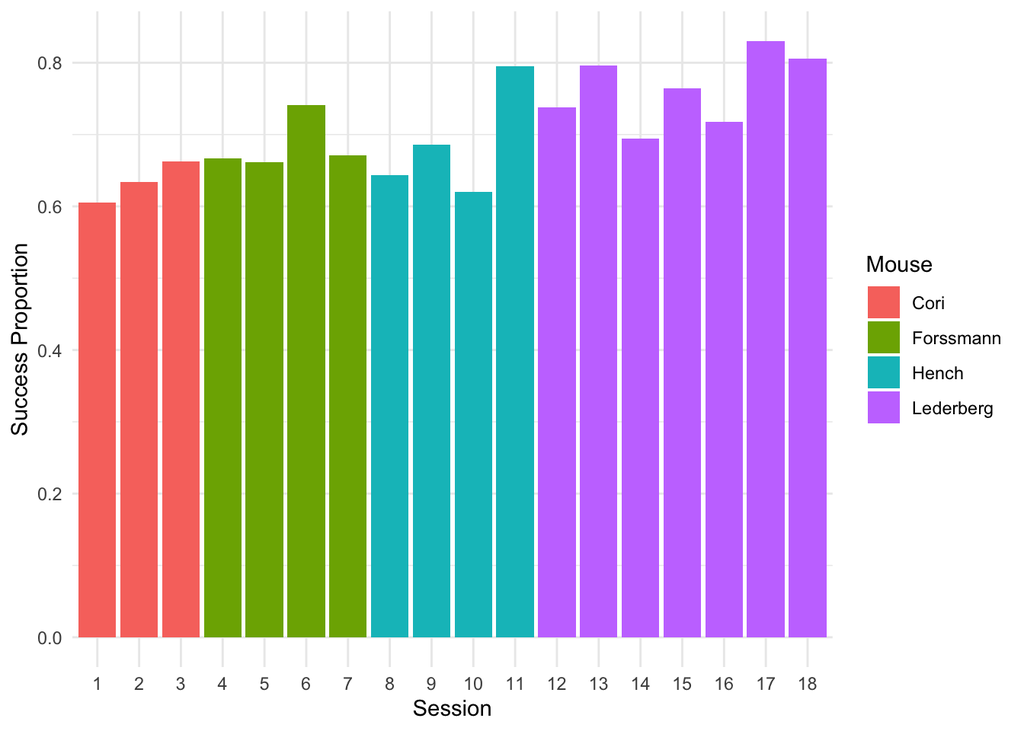

```r
library(ggplot2)

ggplot(proportions, aes(x = Session, y = SuccessProportion, fill = Mouse)) +
  geom_bar(stat = "identity", position = "dodge") +
  labs(x = "Session", y = "Success Proportion") +
  scale_fill_discrete(name = "Mouse") +
  theme_minimal()
```

Since there are differences in the data patterns across sessions, it suggests that the sessions may have unique characteristics that need to be taken into account during data integration. As a result, I will be implementing session-specific, as well as some mouse-specific modeling. The above code computes the proportion of success and failure feedback types across sessions and mice. Here is a visualization of the results in barplot form. It seems that the mouse Lederbreg has a higher average success rate than the othr mice.

```r
library(dplyr)

# Group the data by mouse and calculate the count of success and failure feedback types
proportions <- data %>%
  group_by(Mouse) %>%
  summarize(
    SuccessCount = sum(FeedbackType == 1),
    FailureCount = sum(FeedbackType == 0 | FeedbackType == -1),
    TotalCount = n()
  ) %>%
  ungroup() %>%
  mutate(
    SuccessRate = SuccessCount / TotalCount,
    FailureRate = FailureCount / TotalCount
  )
print(proportions)
```

```
## # A tibble: 4 × 6
##   Mouse     SuccessCount FailureCount TotalCount SuccessRate FailureRate
##   <chr>            <int>        <int>      <int>       <dbl>       <dbl>
## 1 Cori               379          214        593       0.639       0.361
## 2 Forssmann          718          327       1045       0.687       0.313
## 3 Hench              965          446       1411       0.684       0.316
## 4 Lederberg         1546          486       2032       0.761       0.239
```

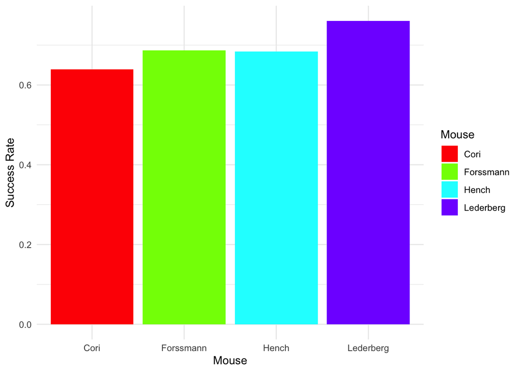

```r
ggplot(proportions, aes(x = Mouse, y = SuccessRate, fill = Mouse)) +
  geom_bar(stat = "identity", position = "dodge") +
  labs(x = "Mouse", y = "Success Rate") +
  scale_fill_manual(values = rainbow(nrow(proportions))) +
  theme_minimal()
```

Here is confirmation of the earlier conjecture, this code provides a summary of the success and failure rates for each mouse, allowing us to look at the feedback patterns across different mice in your dataset. We are able to see in the barplot above that the mouse Lederberg has a much higher success rate than the other mice. This will be useful to know when we are creating our model as a lot of the later sessions are of the mouse Lederberg.

```r
# Group the data by session and mouse and calculate the mean and standard deviation of contrast levels
statistics <- data %>%
  group_by(Session, Mouse) %>%
  summarize(
    MeanContrast = mean(ContrastLeft),
    SDContrast = sd(ContrastLeft)
  ) %>%
  ungroup()
print(statistics)
```

```
## # A tibble: 18 × 4
##    Session Mouse     MeanContrast SDContrast
##    <fct>   <chr>            <dbl>      <dbl>
##  1 1       Cori             0.296      0.354
##  2 2       Cori             0.318      0.400
##  3 3       Cori             0.236      0.353
##  4 4       Forssmann        0.334      0.382
##  5 5       Forssmann        0.339      0.385
##  6 6       Forssmann        0.353      0.387
##  7 7       Forssmann        0.294      0.356
##  8 8       Hench            0.442      0.432
##  9 9       Hench            0.407      0.416
## 10 10      Hench            0.385      0.413
## 11 11      Hench            0.335      0.388
## 12 12      Lederberg        0.289      0.368
## 13 13      Lederberg        0.356      0.399
## 14 14      Lederberg        0.332      0.397
## 15 15      Lederberg        0.339      0.396
## 16 16      Lederberg        0.368      0.408
## 17 17      Lederberg        0.325      0.383
## 18 18      Lederberg        0.319      0.384
```

This code allows us to calculate descriptive statistics for the ContrastLeft variable across different sessions in our dataset. I chose to explore ContrastLeft rather than ContrastRight as when I did ANOVA previously, the F statistic indicated that Contrast Left and Session were the two most informative factors that allowed us to predict Succcess Rate. I was curious if there was variation between each session and ContrastLeft.

```r
# Group the data by mouse and session, calculate the mean and standard deviation of contrast levels
statistics <- data %>%
  group_by(Mouse, Session) %>%
  summarize(
    MeanContrast = mean(ContrastLeft),
    SDContrast = sd(ContrastLeft)
  ) %>%
  group_by(Mouse) %>%
  summarize(
    AverageMeanContrast = mean(MeanContrast),
    AverageSDContrast = mean(SDContrast)
  ) %>%
  ungroup()
print(statistics)
```

```
## # A tibble: 4 × 3
##   Mouse     AverageMeanContrast AverageSDContrast
##   <chr>                   <dbl>             <dbl>
## 1 Cori                    0.283             0.369
## 2 Forssmann               0.330             0.378
## 3 Hench                   0.392             0.412
## 4 Lederberg               0.333             0.391
```

The provided code performs data manipulation and aggregation operations to calculate the average mean contrast and standard deviation of the left contrast for each mouse across sessions. It gives us a better understanding of the average contrast levels and their variation for different mice in the dataset.

CLUSTERING

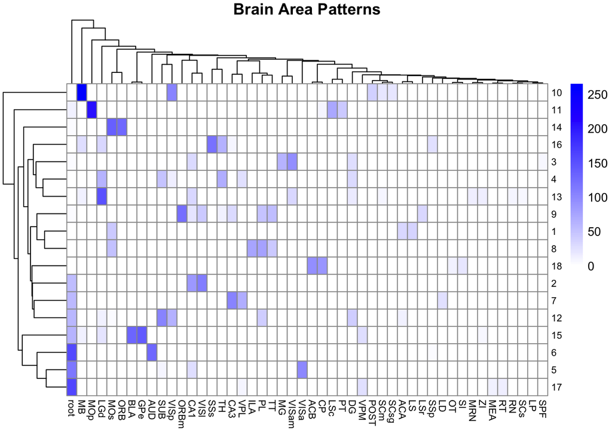

```r
library(pheatmap)

# Create a matrix of brain area counts across sessions and mice
area_matrix <- table(data$Session, data$BrainArea)

# Generate the heatmap
pheatmap(area_matrix,
         main = "Brain Area Patterns",
         col = colorRampPalette(c("white", "blue"))(100),
         fontsize_row = 8,
         fontsize_col = 8,
         cluster_rows = TRUE,
         cluster_cols = TRUE)
```

The code provided generates a heatmap to visualize the patterns of brain areas across sessions, where each cell in the heatmap represents the count or frequency of a specific brain area in a particular session.This helps us identify the distribution and abundance of brain areas across different sessions. The color gradient in the heatmap indicates the intensity or frequency of occurrence of each brain area, where lighter colors represent lower counts, while darker colors (blue) represent higher counts.

By clustering the rows and columns, the heatmap allows us to observe any patterns or similarities in brain area distributions across sessions and mice. For example, we can see that for sessions 2,7,12,15,6,5 and 17, these sessions have higher braain activity in the root compared with all other sessions. Overall, the heatmap provides a visual summary of the brain area patterns, enabling us to identify any trends or differences in brain area occurrences across sessions.

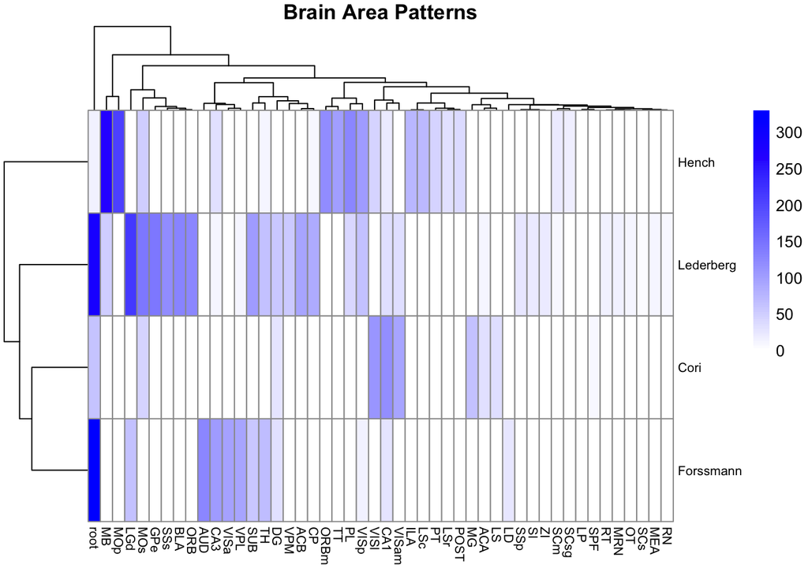

```r
# Create a matrix of brain area counts across sessions and mice
area_matrix <- table(data$Mouse, data$BrainArea)

pheatmap(area_matrix, # Generate the heatmap
         main = "Brain Area Patterns",
         col = colorRampPalette(c("white", "blue"))(100),
         fontsize_row = 8,
         fontsize_col = 8,
         cluster_rows = TRUE,
         cluster_cols = TRUE)
```

The resulting heatmap visualizes the distribution and patterns of brain areas across different mice and sessions. The color intensity in each cell represents the frequency or count of a specific brain area for a particular mouse. For example, we can see that Lederberg and Forssmaann have many counts at the root, while Cori has some counts, and Hench has very little counts.

Part 4 Predictive modeling. Model training and prediction. Finally, we will build a prediction model to predict the outcome (i.e., feedback types). The performance will be evaluated on two test sets of 100 trials randomly selected from Session 1 and Session 18, respectively. The test sets will be released on the day of submission when you need to evaluate the performance of your model.

Here I’m just looking at the feedback type data, and converting any value that is equal to -1 to 0, and any other value to 1. In other words, it is creating a binary representation of the FeedbackType variable where -1 is mapped to 0 and any other value is mapped to 1. I am transform these binary variables into a format suitable for certain analyses or models.

```r
data$FeedbackType <- ifelse(data$FeedbackType == -1, 0, 1)
```

I will be utilizing Supervised Learning: Classification. Here, a logistic regression model is being fitted using the glm function.The family argument is set to binomial, indicating that a logistic regression model should be used, because the response variable takes on two levels. Here I print a summary of the logistic regression model. The summary includes information such as the estimated coefficients, their standard errors, p-values, and other statistical measures related to the model fit. I am choosing to not include Contrast_Right in the model because when I previously included it in the model, the accuracy rate was negartively affected. I am also choosing not to include it in the model because when I ran the ANOVA analysis, Contrast_Right has a F score of 0.000.

```r
library(stats)

# Fit the logistic regression model
model <- glm(FeedbackType ~ Mouse + ContrastLeft + BrainArea,
              data = data,
              family = binomial)

summary(model)
```

```
##
## Call:
## glm(formula = FeedbackType ~ Mouse + ContrastLeft + BrainArea,
##     family = binomial, data = data)
##
## Coefficients:
##                  Estimate Std. Error z value Pr(>|z|)
## (Intercept)      0.691673   0.333546   2.074   0.0381 *
## MouseForssmann   0.123769   0.167372   0.739   0.4596
## MouseHench       0.318207   0.173572   1.833   0.0668 .
## MouseLederberg   0.594561   0.151860   3.915 9.03e-05 ***
## ContrastLeft     0.209181   0.081613   2.563   0.0104 *
## BrainAreaACB     0.207508   0.446431   0.465   0.6421
## BrainAreaAUD     0.005104   0.410656   0.012   0.9901
## BrainAreaBLA    -0.070436   0.409940  -0.172   0.8636
## BrainAreaCA1    -0.208787   0.364899  -0.572   0.5672
## BrainAreaCA3    -0.476097   0.393901  -1.209   0.2268
## BrainAreaCP     -0.078298   0.426377  -0.184   0.8543
## BrainAreaDG     -0.134125   0.396889  -0.338   0.7354
## BrainAreaGPe     0.090995   0.411728   0.221   0.8251
## BrainAreaILA    -0.583768   0.436262  -1.338   0.1809
## BrainAreaLD     -0.102466   0.557400  -0.184   0.8541
## BrainAreaLGd     0.092986   0.380620   0.244   0.8070
## BrainAreaLP     12.848383 378.554278   0.034   0.9729
## BrainAreaLS     -0.301590   0.477167  -0.632   0.5274
## BrainAreaLSc     0.739813   0.499460   1.481   0.1385
## BrainAreaLSr    -0.526846   0.514198  -1.025   0.3056
## BrainAreaMB     -0.863397   0.377153  -2.289   0.0221 *
## BrainAreaMEA     0.928067   1.106440   0.839   0.4016
## BrainAreaMG      0.242205   0.437421   0.554   0.5798
## BrainAreaMOp     0.162962   0.401623   0.406   0.6849
## BrainAreaMOs    -0.642800   0.367945  -1.747   0.0806 .
## BrainAreaMRN    -1.065239   0.644920  -1.652   0.0986 .
## BrainAreaORB    -0.334353   0.404787  -0.826   0.4088
## BrainAreaORBm    0.210193   0.426802   0.492   0.6224
## BrainAreaOT     -0.133079   0.746699  -0.178   0.8585
## BrainAreaPL     -0.265402   0.396190  -0.670   0.5029
## BrainAreaPOST   -0.444050   0.500371  -0.887   0.3748
## BrainAreaPT      0.463035   0.534268   0.867   0.3861
## BrainAreaRN     -1.184594   0.758395  -1.562   0.1183
```

[output cut: 14 more lines]

```
## BrainAreaVISl   -0.417632   0.371446  -1.124   0.2609
## BrainAreaVISp   -0.455504   0.386421  -1.179   0.2385
## BrainAreaVPL     0.061884   0.422410   0.147   0.8835
## BrainAreaVPM    -0.831117   0.450872  -1.843   0.0653 .
## BrainAreaZI     -0.363387   0.594327  -0.611   0.5409
## ---
## Signif. codes:  0 '***' 0.001 '**' 0.01 '*' 0.05 '.' 0.1 ' ' 1
##
## (Dispersion parameter for binomial family taken to be 1)
##
##     Null deviance: 6118.2  on 5080  degrees of freedom
## Residual deviance: 5937.8  on 5029  degrees of freedom
## AIC: 6041.8
##
## Number of Fisher Scoring iterations: 12
```

Here is the Variable Importance Plot, colored in honor of pride month. Unfortunately there are too many variables to label easily on the legend, but this is a visual representation of variable importance, and if we want to look at exact values, we can refer to the earlier model. Overall, this code is fitting a logistic regression model, calculating the variable importance, and visualizing the variable importance using a bar plot with a legend.

```r
library(caret)
```

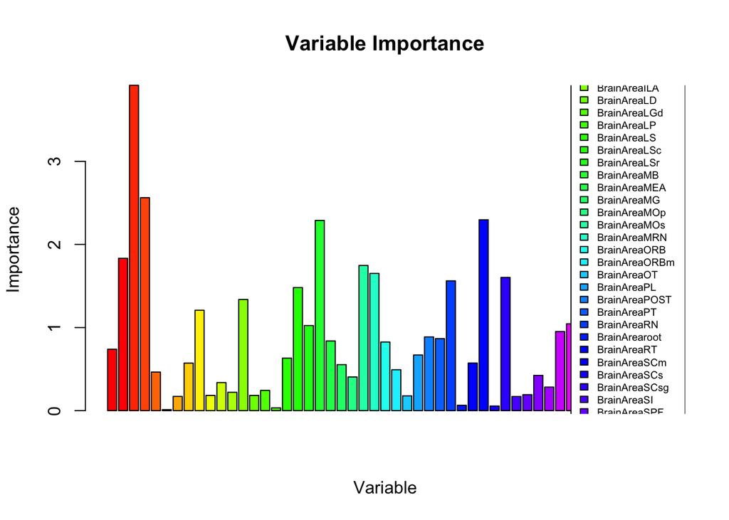

```r
colors<-rainbow(51)

# Fit a logistic regression model
model <- glm(FeedbackType ~ Mouse + ContrastLeft + BrainArea,
              data = data,
              family = binomial)

# Calculate variable importance
var_importance <- varImp(model, scale = FALSE)

var_importance <- data.frame("names"=rownames(var_importance),var_importance)

# Plot variable importance
barplot(var_importance$Overall, xlab="Variable", ylab="Importance", main="Variable Importance", col=colors)

legend("right", legend=var_importance$names, fill=colors, cex=0.6)
```

Here I define the test and training set and build a prediction model. The p argument specifies the proportion of data to be assigned to the training set (in this case, 80% for training and 20% for testing). The set.seed function is used to set a random seed for reproducibility.

```r
# Split the data into 80% training and 20% testing
set.seed(123)
train_index <- createDataPartition(data$FeedbackType, p = 0.8, list = FALSE)
training_data <- data[train_index, ]
testing_data <- data[-train_index, ]

# Update the levels of BrainArea in testing_data
#testing_data$BrainArea <- factor(testing_data$BrainArea, levels = levels(training_data$BrainArea))

# Fit a logistic regression model
model <- glm(FeedbackType ~ Mouse + ContrastLeft + BrainArea, data = training_data, family = binomial)

summary(model)
```

```
##
## Call:
## glm(formula = FeedbackType ~ Mouse + ContrastLeft + BrainArea,
##     family = binomial, data = training_data)
##
## Coefficients:
##                  Estimate Std. Error z value Pr(>|z|)
## (Intercept)      0.454636   0.360367   1.262 0.207096
## MouseForssmann   0.179576   0.188124   0.955 0.339798
## MouseHench       0.302061   0.195690   1.544 0.122692
## MouseLederberg   0.595029   0.170560   3.489 0.000485 ***
## ContrastLeft     0.202254   0.091784   2.204 0.027554 *
## BrainAreaACB     0.526700   0.492087   1.070 0.284467
## BrainAreaAUD     0.321534   0.447671   0.718 0.472611
## BrainAreaBLA     0.200019   0.442806   0.452 0.651480
## BrainAreaCA1    -0.020267   0.395437  -0.051 0.959125
## BrainAreaCA3    -0.285037   0.428039  -0.666 0.505466
## BrainAreaCP      0.169049   0.462562   0.365 0.714766
## BrainAreaDG      0.204499   0.430972   0.475 0.635138
## BrainAreaGPe     0.339489   0.443273   0.766 0.443755
## BrainAreaILA    -0.399019   0.470606  -0.848 0.396502
## BrainAreaLD      0.040384   0.628665   0.064 0.948781
## BrainAreaLGd     0.176393   0.410118   0.430 0.667122
## BrainAreaLP     14.111432 882.743449   0.016 0.987246
## BrainAreaLS     -0.020864   0.524962  -0.040 0.968298
## BrainAreaLSc     0.787602   0.525264   1.499 0.133760
## BrainAreaLSr    -0.138131   0.586126  -0.236 0.813691
## BrainAreaMB     -0.522199   0.409022  -1.277 0.201708
## BrainAreaMEA    13.437792 333.433527   0.040 0.967853
## BrainAreaMG      0.576047   0.490091   1.175 0.239840
## BrainAreaMOp     0.415764   0.435625   0.954 0.339877
## BrainAreaMOs    -0.372802   0.398453  -0.936 0.349467
## BrainAreaMRN    -0.940514   0.714287  -1.317 0.187933
## BrainAreaORB    -0.038482   0.438912  -0.088 0.930134
## BrainAreaORBm    0.338902   0.461097   0.735 0.462345
## BrainAreaOT     -0.400736   0.802195  -0.500 0.617393
## BrainAreaPL      0.064071   0.431337   0.149 0.881917
## BrainAreaPOST   -0.192996   0.531755  -0.363 0.716649
## BrainAreaPT      0.683336   0.599726   1.139 0.254530
## BrainAreaRN     -0.225324   0.918790  -0.245 0.806270
```

[output cut: 14 more lines]

```
## BrainAreaVISl   -0.123795   0.405845  -0.305 0.760342
## BrainAreaVISp   -0.211058   0.420770  -0.502 0.615950
## BrainAreaVPL     0.288838   0.463316   0.623 0.533013
## BrainAreaVPM    -0.791152   0.488429  -1.620 0.105278
## BrainAreaZI     -0.002827   0.640232  -0.004 0.996477
## ---
## Signif. codes:  0 '***' 0.001 '**' 0.01 '*' 0.05 '.' 0.1 ' ' 1
##
## (Dispersion parameter for binomial family taken to be 1)
##
##     Null deviance: 4890.4  on 4064  degrees of freedom
## Residual deviance: 4761.6  on 4013  degrees of freedom
## AIC: 4865.6
##
## Number of Fisher Scoring iterations: 13
```

Here I evaluate the performance of a binary classification model by comparing its predictions with the actual classes in some makeshift testing data. The confusion matrix provides a comprehensive summary of the model’s performance in terms of correct and incorrect predictions. Some ways I could optimize this model would be to lower or raise the threshold value.

```r
# Make predictions on the testing data
predictions <- predict(model, newdata = testing_data, type = "response")

# Convert predictions to binary class labels
predicted_classes <- ifelse(predictions > 0.6, 1, 0)

predicted_classes=as.numeric(predicted_classes)

# Create a confusion matrix
confusion_matrix <- confusionMatrix(data = as.factor(predicted_classes), reference = as.factor(testing_data$FeedbackType))

# Print the confusion matrix
print(confusion_matrix)
```

```
## Confusion Matrix and Statistics
##
##           Reference
## Prediction   0   1
##          0  38  53
##          1 259 666
##
##                Accuracy : 0.6929
##                  95% CI : (0.6635, 0.7212)
##     No Information Rate : 0.7077
##     P-Value [Acc > NIR] : 0.8574
##
##                   Kappa : 0.0681
##
##  Mcnemar's Test P-Value : <2e-16
##
##             Sensitivity : 0.12795
##             Specificity : 0.92629
##          Pos Pred Value : 0.41758
##          Neg Pred Value : 0.72000
##              Prevalence : 0.29232
##          Detection Rate : 0.03740
##    Detection Prevalence : 0.08957
##       Balanced Accuracy : 0.52712
##
##        'Positive' Class : 0
##
```

Section 5 Prediction performance on the test sets.

Unzipping the files

```r
zip_file_path <- "./test.zip"

# Set the destination folder to extract the files
destination_folder <- "./Data"

# Create the Data folder if it doesn't exist
dir.create(destination_folder, showWarnings = FALSE)

# Unzip the sessions.zip file to the Data folder
unzip(zipfile = zip_file_path, exdir = destination_folder)

data_files <- list.files(destination_folder)
```

Checking to make sure I am able to open the files

```r
the_test=list()
for(i in 1:2){
  the_test[[i]]=readRDS(paste('./Data/test',i,'.rds',sep=''))
   print(the_test[[i]]$mouse_name)
   print(the_test[[i]]$date_exp)
}
```

```
## [1] "Cori"
## [1] "2016-12-14"
## [1] "Lederberg"
## [1] "2017-12-11"
```

Here, I am creating a dataset of the test data for my variables of interest.

```r
the_test_data <- data.frame(Session = factor(),
                   Mouse = character(),
                   FeedbackType = numeric(),
                   ContrastLeft = numeric(),
                   ContrastRight = numeric(),
                   BrainArea = character(),
                   stringsAsFactors = FALSE)

for (i in 1:2) {
  session_test_data <- the_test[[i]]
  the_num_of_trials <- 100

  for (j in 1:the_num_of_trials) {
    feedback_type <- session_test_data$feedback_type[j]
    contrast_left <- session_test_data$contrast_left[j]
    contrast_right <- session_test_data$contrast_right[j]

    # Determine the corresponding mouse and brain area based on the session index
    mouse <- ifelse(i %in% c(1, 2, 3), "Cori",
                    ifelse(i %in% c(4, 5, 6, 7), "Forssmann",
                           ifelse(i %in% c(8, 9, 10, 11), "Hench", "Lederberg")))

    brain_area <- session_test_data$brain_area[j]
    the_test_data <- rbind(the_test_data, data.frame(Session = i,
                                   Mouse = mouse,
                                   FeedbackType = feedback_type,
                                   ContrastLeft = contrast_left,
                                   ContrastRight = contrast_right,
                                   BrainArea = brain_area))
  }
}
```

Here I am once again changing the feedback of our test set to be 0 if no success, and 1 if success just so that the feedbacktype is consistent accross datasets.

```r
the_test_data$FeedbackType <- ifelse(the_test_data$FeedbackType == -1, 0, 1)
```

The overall accuracy of the model is calculated to be 0.64, indicating that it correctly classified 64% of the instances. However, it is important to consider additional metrics to assess the model’s performance comprehensively. The Kappa statistic, which measures agreement beyond chance, is 0.0316, indicating only slight agreement between predicted and reference values.

The sensitivity, or true positive rate, is 0.2364, suggesting the proportion of actual positive cases correctly identified by the model. The specificity, or true negative rate, is 0.7931, representing the proportion of actual negative cases correctly identified. The positive predictive value (PPV) is 0.3023, indicating the proportion of predicted positives that are true positives. The negative predictive value (NPV) is 0.7325, representing the proportion of predicted negatives that are true negatives.

The prevalence, which is the proportion of positive cases in the dataset, is 0.2750. The detection rate, or the proportion of actual positive cases correctly identified by the model, is 0.0650. The detection prevalence, which is the proportion of predicted positive cases, is 0.2150.

```r
# Make predictions on the testing data
predictions <- predict(model, newdata = the_test_data, type = "response")

# Convert predictions to binary class labels
predicted_classes <- ifelse(predictions > 0.6, 1, 0)

predicted_classes=as.numeric(predicted_classes)

# Create a confusion matrix
confusion_matrix <- confusionMatrix(data = as.factor(predicted_classes), reference = as.factor(the_test_data$FeedbackType))

# Print the confusion matrix
print(confusion_matrix)
```

```
## Confusion Matrix and Statistics
##
##           Reference
## Prediction   0   1
##          0  13  30
##          1  42 115
##
##                Accuracy : 0.64
##                  95% CI : (0.5693, 0.7065)
##     No Information Rate : 0.725
##     P-Value [Acc > NIR] : 0.9966
##
##                   Kappa : 0.0316
##
##  Mcnemar's Test P-Value : 0.1949
##
##             Sensitivity : 0.2364
##             Specificity : 0.7931
##          Pos Pred Value : 0.3023
##          Neg Pred Value : 0.7325
##              Prevalence : 0.2750
##          Detection Rate : 0.0650
##    Detection Prevalence : 0.2150
##       Balanced Accuracy : 0.5147
##
##        'Positive' Class : 0
##
```

```r
# Make predictions on the testing data
predictions <- predict(model, newdata = the_test_data, type = "response")

# Convert predictions to binary class labels
predicted_classes <- ifelse(predictions > 0.63, 1, 0)

predicted_classes=as.numeric(predicted_classes)

# Create a confusion matrix
confusion_matrix <- confusionMatrix(data = as.factor(predicted_classes), reference = as.factor(the_test_data$FeedbackType))

# Print the confusion matrix
print(confusion_matrix)
```

```
## Confusion Matrix and Statistics
##
##           Reference
## Prediction  0  1
##          0 28 59
##          1 27 86
##
##                Accuracy : 0.57
##                  95% CI : (0.4983, 0.6396)
##     No Information Rate : 0.725
##     P-Value [Acc > NIR] : 0.9999991
##
##                   Kappa : 0.0866
##
##  Mcnemar's Test P-Value : 0.0008293
##
##             Sensitivity : 0.5091
##             Specificity : 0.5931
##          Pos Pred Value : 0.3218
##          Neg Pred Value : 0.7611
##              Prevalence : 0.2750
##          Detection Rate : 0.1400
##    Detection Prevalence : 0.4350
##       Balanced Accuracy : 0.5511
##
##        'Positive' Class : 0
##
```

Discussion

However, it’s important to note that accuracy alone may not provide a complete picture of model performance. Other metrics such as sensitivity, specificity, positive predictive value, and negative predictive value should also be taken into account. Additionally, the context and specific requirements of the application should be considered when choosing a model.

Upon comparing the additional performance metrics between the two models, we find that the second model has a higher sensitivity, indicating a better ability to correctly detect the positive cases, while the first model exhibits a higher specificity, suggesting a lower false positive rate. However, both models show relatively low positive predictive values, implying a significant number of false positives. In terms of negative predictive values, the second model performs slightly better. Considering the balanced accuracy, which considers both sensitivity and specificity, the second model has a slightly higher value. Overall, neither model demonstrates exceptional performance in terms of accuracy, sensitivity, or specificity. Thus, selecting the better model would require a more comprehensive analysis, considering the specific objectives, requirements, and trade-offs of the application.

However, for our purposes, I am considering accuracy as the criterion for selecting a model. Thus the first model (threshold of 0.6) with an accuracy of 64%, is the model I have selected for our general prediction purposes.

# Reference

ChatGPT, Claire Hsieh, Sai, Materials from Professor S.Chen, https://www.nature.com/articles/nn1228

Steinmetz, N.A., Zatka-Haas, P., Carandini, M. et al. Distributed coding of choice, action and engagement across the mouse brain. Nature 576, 266–273 (2019). https://doi.org/10.1038/s41586-019-1787-x